## Grunnleggende bakgrunnkunnskaper og enkel Keynes modell (lukket økonomi)

### Stabiliseringsmål lukket økonomi

Intern balanse (lukke produksjonsgapet):

$$(Y-\overline{Y})=0$$

### Sentrale nasjonalregnskapstall

- Bruttonasjonalprodukt (GDP/BNP): Den samlede verdien av alle varer og tjenester som blir produsert i landet i løpet av et år
  - Nominelt BNP (LY)
    $$LY = PY$$
  - Reelt BNP (Y)
    $$LY/P = Y$$
- Bruttonasjonalinntekt (GNP/BNI): Den samlede verdien av alle varer og tjenester som landets innbyggere produserer i løpet av et år
- Arbeidsledighetsrate:

$$u = 1-\frac{L}{N}$$

- Inflasjon:

$$\pi = \frac{P_{1} - P_{0}}{P_{0}}$$

### Noen sentrale empiriske sammenhenger

#### Okuns lov: negativ korrelasjon mellom endring i arbeidsledighet og vekst (eller endring) BNP (realpriser)

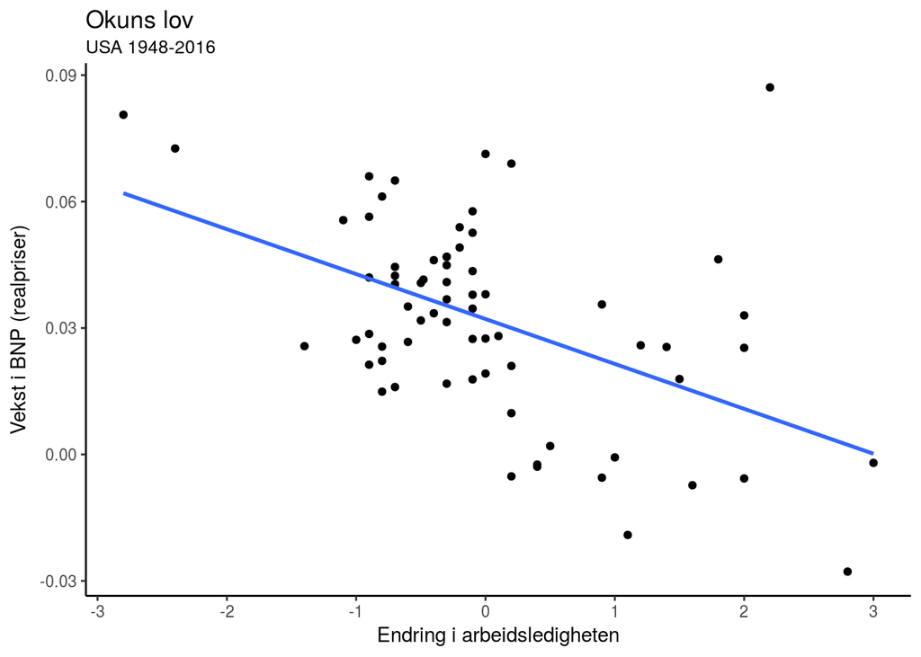

#### Phillips-kurven: sammenheng mellom arbeidsledighet og endring i inflasjon (eller inflasjon)

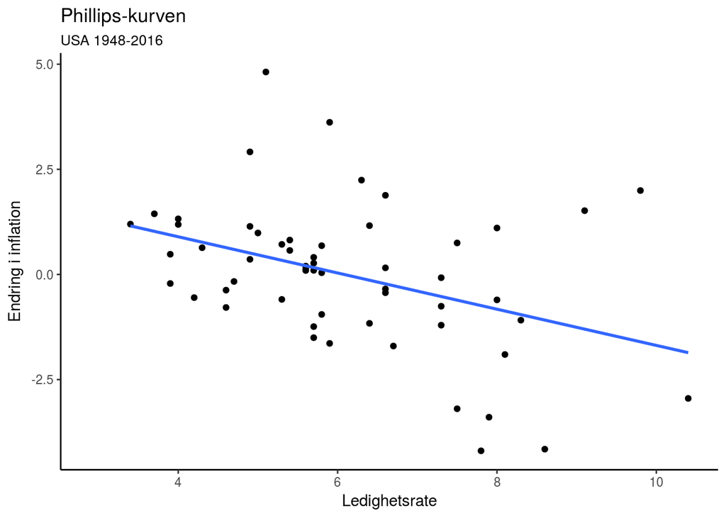

### Hva bestemmer aggregert BNP?

#### Kort sikt (0-3 år):

- Pga av antagelsen om at produktpriser og lønninger ikke endrer seg på kort sikt (og statiske prisforventninger), vil samlet etterspørsel ($AE$) bestemmer BNP ($Y$)
- Vi legger dette til grunn i enkel Keynes, IS-LM, og Mundell-Fleming modellen (del I og del III)

#### Mellomlang sikt (5-10 år):

- Tilgangen på innsatsfaktorene arbeidskraft ($L$), teknkologi ($A$) og kapital ($K$) bestemmer BNP ($Y$)
- Langsiktig likevekstbetingelse for AD-AS modellen (del I)

#### Lang sikt (10-50 år):

- Teknologisk framgang ($a$), kapitalakkumalasjon ($\Delta K$) og befolkningsvekst ($n$) bestemmer BNP ($Y$)
- Hovedresultatet fra Solow-modellen (del II)

### Enkel Keynes-modell

- Likevekt i godemarkedet (varer og tjenester)

#### Aggregert etterspørsel (AE)

$$AE \equiv C + I + G$$

#### Markeder i likevekt: Godemarkedet (varer og tjenester)

$$Y = AE$$

#### Husholdninger

$$C = \overline{C} + c(Y - T)$$

Hvor $0<c<1$ og $\overline{C}>0$

#### Bedrifter

$$I = \overline{I} - b\cdot i$$

Hvor $\overline{I}>0$ og $b>1$ og

#### Sentralbanken

$$i = \overline{i}$$

Hvor $\overline{i} \geqslant 0$

#### Offentlige myndigheter

$$G = \overline{G}$$
og
$$T = \overline{T}$$

#### Løsning av modellen:

Setter adferdslikningene inn i likevekstbetingelsen for godemarkedet

$$Y = \overline{C} + c(Y - T) + \overline{I} - b\cdot i + \overline{G}$$

Løser modellen mhp. på Y (godemarkedet)

Endogene variabler: $Y$

Eksogene variabler: $\overline{C}, \overline{T}, \overline{i}, \overline{I}, \overline{G}$

Parametre: $c, b$

- Grafisk framvisning

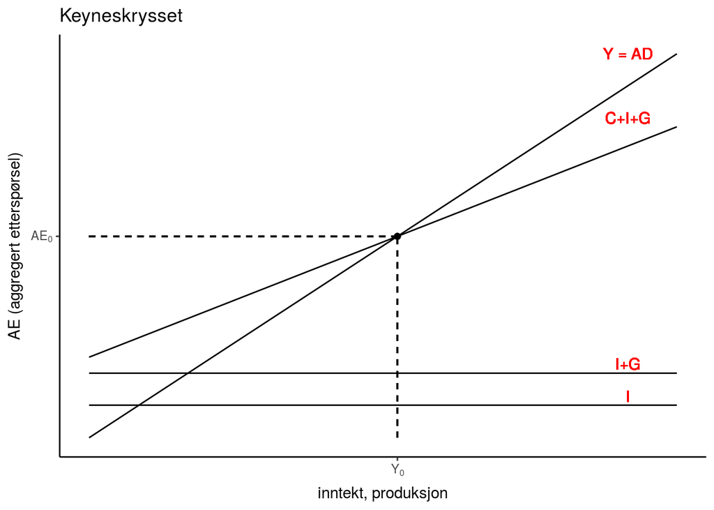

#### Komparativ statikk (analyse fra en likevekt til en annen):

Økte investeringer (‘animal spirits’) $\Delta{\overline{I}}>0$

- **F**ormelt:

$$\Delta Y = \frac{1}{1-c}\Delta \overline{I}>0$$

- **V**erbalt (tolkning utenfor modellen):

Økte investeringer $\rightarrow$ økt produksjon $\rightarrow$ initierer en multiplikatoreffekt: $\rightarrow$ økt disponibel inntekt $\rightarrow$ økt konsum $\rightarrow$ økt produksjon etc.

- **G**rafisk:

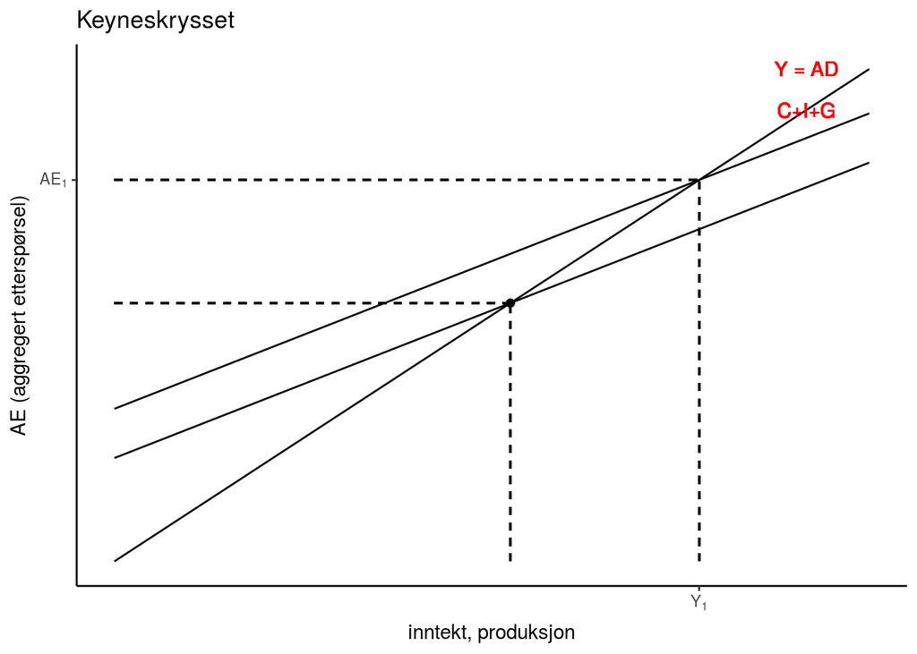

#### Stabiliseringspolitikk

Reduserte offentlige utgifter $\Delta G < 0$

$$\Delta Y = \frac{1}{1-c} \left [ \Delta \overline{I} + \Delta \overline{G} \right ]$$

Dersom vi lar $\Delta \overline{I} = - \Delta \overline{G} > 0 \Rightarrow \Delta Y = 0$ (dvs. intern balanse)

I praksis kan det som regel være vanskelig å benytte finanspolitikk som konjunkturstabiliserende virkemiddel, siden det politiske systemet som oftest innehar innebygde tregheter tilknyttet endringer i finanspolitikken (eks. må godkjennes av Storting og regjering)

#### Øvelse

Redusert rentenivå $\Delta{{i}}<0$

- **F**ormelt:
- **G**rafisk (Y, i plan):
- **V**erbalt (tolkning utenfor modellen):